# W3cubDocs

/Kotlin

# Getting Started with Eclipse IDE

| **Last Updated** | 24 April 2019 |
| --- | --- |

This tutorials walks us through creating a simple Hello World application using Eclipse IDE

## Setting up the environment

First of all, you need the Eclipse IDE installed on your system. You can download its latest version from [download page](https://www.eclipse.org/downloads/). The "Eclipse IDE for Java Developers" bundle is recommended.

Alternatively, open the **Help | Eclipse Marketplace…** menu and search for **Kotlin Plugin for Eclipse**:

[figure not shown]

A more old-fashioned way is using an *update site* directly:

```
https://dl.bintray.com/jetbrains/kotlin/eclipse-plugin/last/
```

Once the plugin is installed and Eclipse is restarted, make sure the plugin is installed correctly: open the **Kotlin perspective** in the menu **Window | Open Perspective | Other…**

[figure not shown]

## Creating a new project

Now you are ready to create a new Kotlin project.

1. Select **File | New | Kotlin Project**.

[figure not shown]

   An empty Kotlin/JVM project will be created. For Eclipse IDE, the project is also a Java project but configured with Kotlin nature, meaning it has the Kotlin Builder and reference to the Kotlin Runtime Library. Great thing about this solution is that you can add both Kotlin and Java code to the same project.

   The project structure looks like this:

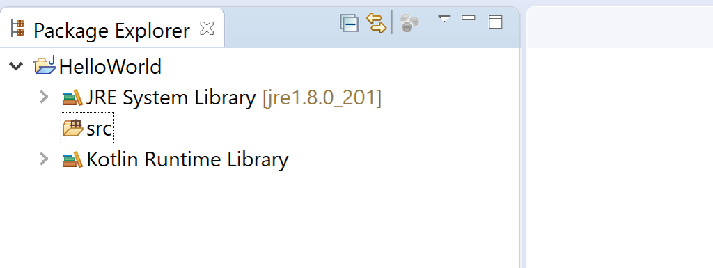

2. Create a new Kotlin file in the the source directory.

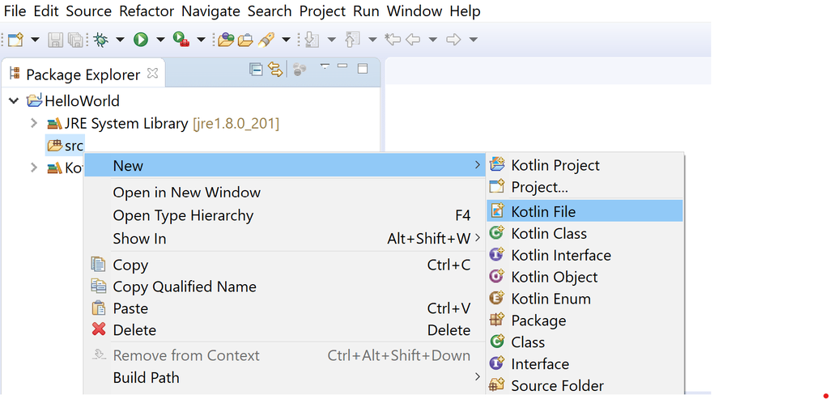

   You can enter the name without the **.kt** extension. Eclipse will add it automatically.

[figure not shown]

3. Once you have a source file, add the `main` function - the entry point to a Kotlin application. You can simply type `main` and invoke code completion by hitting `Ctrl + Space`.

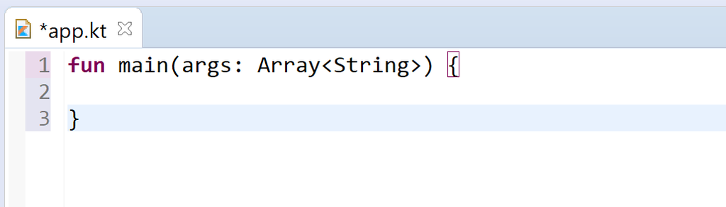

4. Add a simple line of Kotlin code to print a message:

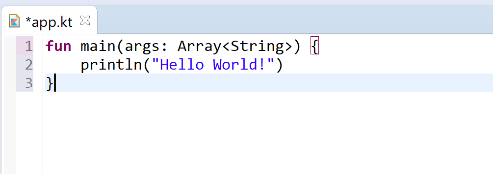

## Running the application

To run the application, right-click somewhere in the main file and select **Run As | Kotlin Application**.

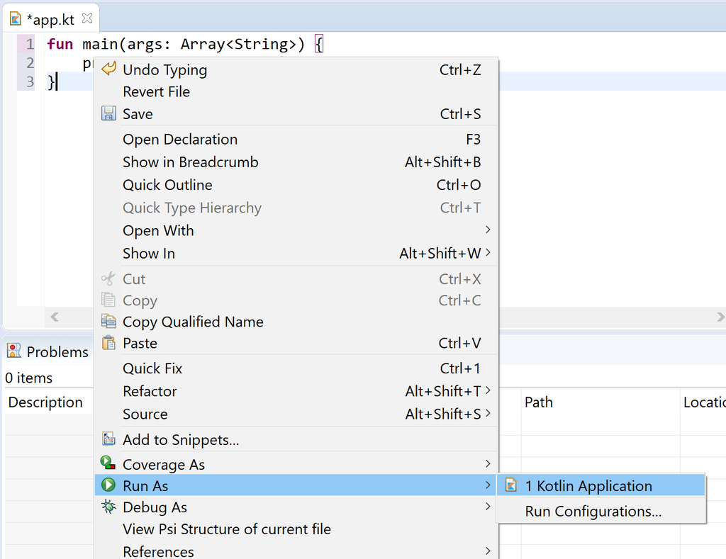

If everything went well, you'll see the result in the **Console** window.

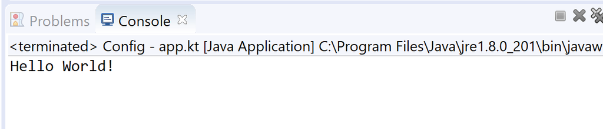

Congratulations! You now have your Kotlin application running in Eclipse IDE.

© 2010–2020 JetBrains s.r.o. and Kotlin Programming Language contributors  
Licensed under the Apache License, Version 2.0.  
https://kotlinlang.org/docs/tutorials/getting-started-eclipse.html